# Verzani Problem Set

Next are considered the problems from Verzani’s book on page 47.

## Problem 6.4

Toss a fair coin 50 times (using R). How many heads do you have?

```r
> coin <- sample(c("Head","Tail"), size = 50, replace = TRUE)
> sum(coin == "Head")
[1] 27
```

Or use the binomial distribution $Bi(50, 0.5)$ directly.

```r
> rbinom(1, 50, 0.5)
[1] 29
```

## Problem 6.5

Roll a “die” 100 times. How many 6’s did you see?

```r
> die <- sample(1:6, size = 100, replace = TRUE)
> sum(die == 6)
[1] 12
```

Or use the binomial distribution $Bi(100, \frac{1}{6})$ directly.

```r
> rbinom(1, 100, 1/6)
[1] 14
```

## Problem 6.6

Select 6 numbers from a lottery containing 49 balls. What is the largest number? What is the smallest?

```r
> lottery <- sample(1:49, 6, replace = FALSE); lottery
[1] 30 25 37  7 38  8
> min(lottery)
[1] 7
> max(lottery)
[1] 38
```

How many even numbers do you have? Estimate the probability to have an even number.

```r
> sum(lottery %% 2 == 0)
[1] 3
> sum(lottery %% 2 == 0) / length(lottery)
[1] 0.5
```

Or use the hypergeometric distribution $HG(24, 25, 6)$ directly.

```r
> rhyper(1, 24, 25, 6)
[1] 2
```

Compute the theoretical probability to have 2 even numbers?

```r
> dhyper(2, 24, 25, 6)
[1] 0.2496743
```

## Problem 6.12

Use R to pick 5 cards from a deck of 52.

```r
> cards <- paste(rep(c("Ace",2:10,"Jack","Queen","King"), 4),
+                c("Heart","Diamond","Spade","Club"))
> x <- sample(x = cards, size = 5); x
[1] "5 Heart"   "10 Spade"  "3 Club"    "2 Diamond" "2 Spade"
```

Did you get a pair or better? We say that a pair of cards is two cards with one and the same number(letter).

```r
> y <- sub(pattern = " .*$",replacement = "" , x); y
[1] "5"  "10" "3"  "2"  "2"
> length(y) - length(unique(y))
[1] 1
```

Repeat until you do. How long did it take?

```r
> z <- function(){
+   r <- 0
+   cards <- paste(rep(c("Ace",2:10,"Jack","Queen","King"), 4),
+                  c("Heart","Diamond","Spade","Club"))
+   repeat {
+     x <- sample(x = cards, size = 5)
+     y <- sub(pattern = " .*$", replacement = "" , x)
+     if (length(y) - length(unique(y)) != 0){
+       break
+     } else {
+       r <- r + 1
+     }
+   }
+   r
+ }
> z()
[1] 0
```

Repeat the trail $1000$ times, plot the histogram and estimate the probability to have the first pair or better on the second trail.

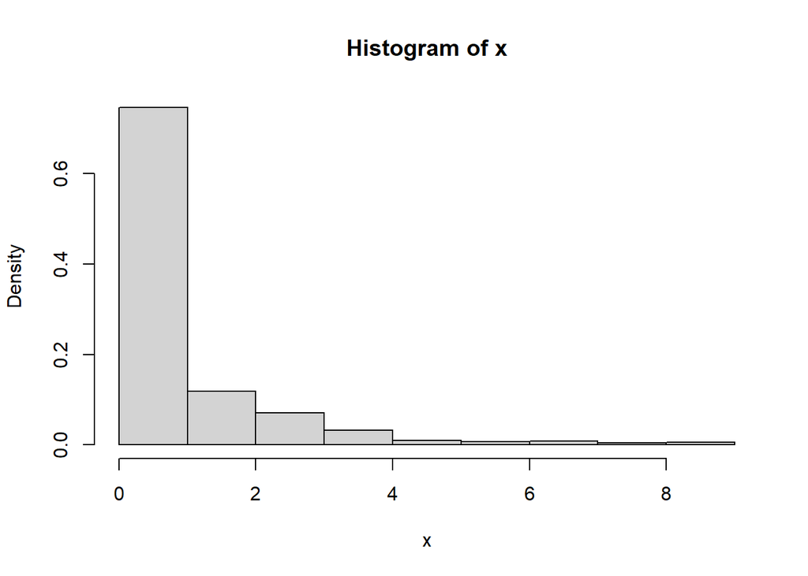

```r
> x <- replicate(1000, z())
> hist(x,
+      probability = TRUE)
```

```r
> sum(x == 1) / length(x)
[1] 0.262
```

By using the classical definition of probability compute the theoretical probability of the event $A$ to have a pair or better
$$P(\bar{A}) = \frac{52*48*44*40*36}{52*51*50*49*48} \approx 0.5071$$
$$P(A) = 1 - P(\bar{A}) = 1 - 0.5071 = 0.4929$$
Generate the number of the trails before the first pair or better by using the geometric distribution $Geom(0.4929)$.

```r
> rgeom(1, prob = 0.4929)
[1] 3
```

Compute the probability to have the first pair or better on the second trail

```r
> dgeom(1, prob = 0.4929)
[1] 0.2499496
```

What is the difference if we have replacement?
$$P(\bar{A}) = \frac{52*48*44*40*36}{52*52*52*52*52} \approx 0.4160$$
$$P(A) = 1 - P(\bar{A}) = 1 - 0.4160 = 0.5840$$

Generate the number of the trails before the first pair or better by using the geometric distribution $Geom(0.5840)$.

```r
> rgeom(1, prob = 0.5840)
[1] 2
```

Compute the probability to have the first pair or better on the second trail

```r
> dgeom(1, prob = 0.5840)
[1] 0.242944
```